# Velocity model v0.4.1: v0.4.0 re-inverted with the tomoDD floor (D-B083)

v0.4.0 (v0.3.1 configuration, re-timed picks) re-inverted with tomoDD's event updates floored at the local solid surface (D-B081 floor in the inversion, D-B083); product as D-B076: medium (rock / water / air at the D-B068 merged surface), D-B073 shallow-crust node rule, Vp_tomography / Vs_tomography = the inversion values, NonLinLoc grids by the field rule. Generated by workflow/10_tomography/b2_v041_analyse.py (branch tomo/v041-floor). Floor = D-B081 (tomoDD-SE 2026-11-25 freeze): an event update that would put the event above the floor depth of the nearest surface.dat node stops 1 m below it; the event is kept and logged. surface.dat = conservative floor of the D-B068 merged surface (exact cell minimum - 1 m; M0 45 s, tiles 30 s, the 1001-node limit), in each stage's rescaled frame (D-B028 P-2). Air_dep -1000 km. Velocities above the surface stay rock-continued in the inversion (D-B083). Everything else as v0.4.0: same inputs, damping 200, smoothing (M0 480, blanco 20, others 480), merge rules D-B049 (v0.3.1 d200 masks), D-B050, D-B051.

## 1. Binary identity without surface.dat (step 1)

Each v0.4.0 run below was rerun with the 2026-11-25 inversion binary of its size class, same inputs, tomoDD-SE.inp and MOD, no surface.dat; every Output_Files file compared byte for byte (cmp).

| run | binary | binary_md5 | exit | output_files | different | log_identical | wall_min |
| --- | --- | --- | --- | --- | --- | --- | --- |
| blanco_m0t_d200_s20 | tomoDD-SE_e10k | 9cdc329c0976 | exit 0 | 20 | [tomoDD-SE.log, stdout.txt] | False | 24 |
| margin_m0_v3_d200_s480 | tomoDD-SE_m | a334ef5e0c78 | exit 0 | 20 | [tomoDD-SE.log, stdout.txt] | False | 33.6 |
| mendocino_gorda_c_m0t_d200_s480 | tomoDD-SE_e13k | c441d6ad7814 | exit 0 | 20 | [tomoDD-SE.log, stdout.txt] | False | 55.5 |
| washington_m0t_d200_s480 | tomoDD-SE_w | aee014d37d67 | exit 0 | 20 | [tomoDD-SE.log, stdout.txt] | False | 76.1 |

## 2. surface.dat writer (step 2)

Start hypocentres (event.dat, the v0.4.0 starts) against the exact merged surface at their true position and against the floor tomoDD reads at their rescaled position (float32 nearest-node rule reproduced). 'below surface but above floor': below the true surface, but in the cell-minimum gap, so their first upward update stops at the floor. Node choice: tomoDD's node vs NonLinLoc's rule at the true position.

| stage | region | spacing_s | nodes | events | below_true_surface | above_true_surface_at_start | below_surface_but_above_floor | floor_below_surface_m_p50_p90_p99_max | floor_below_surface_min_m | node_mismatch | float32_edge_ties |
| --- | --- | --- | --- | --- | --- | --- | --- | --- | --- | --- | --- |
| M0 | margin_m0_v4 | 45 | 945 x 939 | 6943 | 6930 | 13 | 18 | [28.2, 176.0, 421.9, 989.6] | 1 | 0 | 3 |
| M0 | margin_m0_v4nf | 45 | 945 x 939 | 6943 | 6930 | 13 | 18 | [28.2, 176.0, 421.9, 989.6] | 1 | 0 | 3 |
| mendocino_gorda_c | mendocino_gorda_c_m0f | 30 | 565 x 793 | 12191 | 12187 | 4 | 7 | [27.1, 158.9, 290.0, 487.9] | 1 | 0 | 19 |
| mendocino_gorda_c | mendocino_gorda_c_m0fnf | 30 | 565 x 793 | 12191 | 12187 | 4 | 7 | [27.1, 158.9, 290.0, 487.9] | 1 | 0 | 19 |
| blanco | blanco_m0f | 30 | 445 x 793 | 4378 | 4372 | 6 | 2 | [61.9, 214.9, 462.6, 696.7] | 1.086 | 0 | 1 |
| blanco | blanco_m0fnf | 30 | 445 x 793 | 4378 | 4372 | 6 | 2 | [61.9, 214.9, 462.6, 696.7] | 1.086 | 0 | 1 |
| oregon | oregon_m0f | 30 | 589 x 802 | 3390 | 3386 | 4 | 4 | [21.0, 73.2, 153.8, 342.2] | 1.046 | 0 | 5 |
| oregon | oregon_m0fnf | 30 | 589 x 802 | 3390 | 3386 | 4 | 4 | [21.0, 73.2, 153.8, 342.2] | 1.046 | 0 | 5 |
| washington | washington_m0f | 30 | 613 x 841 | 9332 | 9329 | 3 | 18 | [24.1, 103.6, 307.4, 763.7] | 1 | 0 | 5 |
| washington | washington_m0fnf | 30 | 613 x 841 | 9332 | 9329 | 3 | 18 | [24.1, 103.6, 307.4, 763.7] | 1 | 0 | 5 |

Listed start hypocentres (above the true surface at start, or below it and above the floor):

| ID | region | lat | lon | depth_bsl_km | surface_depth_km | floor_tomodd_km | floor_true_km | below_surface | below_floor | floor_minus_surface_m | stage |
| --- | --- | --- | --- | --- | --- | --- | --- | --- | --- | --- | --- |
| 8893 | Cascades | 46.18 | -122.1 | -1.421 | -1.371 | -1.316 | -1.316 | False | False | 55.03 | M0 |
| 17008 | Other onshore | 43.5 | -122.9 | -0.9418 | -0.9586 | -0.9404 | -0.9405 | True | False | 18.2 | M0 |
| 39842 | Gorda | 41.95 | -127.2 | 3.633 | 3.61 | 3.639 | 3.639 | True | False | 29.58 | M0 |
| 42131 | Blanco | 43.26 | -127.4 | 2.895 | 2.953 | 3.029 | 3.029 | False | False | 75.63 | M0 |
| 43131 | Mendocino | 40.36 | -125.2 | 1.604 | 1.576 | 1.822 | 1.822 | True | False | 245.9 | M0 |
| 45759 | Gorda | 42.45 | -127 | 2.969 | 3.014 | 3.114 | 3.114 | False | False | 99.6 | M0 |
| 47644 | Blanco | 43.43 | -127.9 | 2.969 | 2.756 | 3.08 | 3.08 | True | False | 324.3 | M0 |
| 50672 | Gorda | 42.48 | -126.8 | 3.485 | 3.046 | 3.537 | 3.537 | True | False | 491.3 | M0 |
| 51735 | Offshore forearc | 49.69 | -124.5 | -0.0564 | -0.06002 | 0.0504 | 0.05039 | True | False | 110.4 | M0 |
| 53936 | Gorda | 42.48 | -126.9 | 2.858 | 2.947 | 3.432 | 3.432 | False | False | 484.7 | M0 |
| 55959 | Other onshore | 43.92 | -123.7 | -0.6098 | -0.7322 | -0.5041 | -0.5042 | True | False | 228.1 | M0 |
| 63899 | Blanco | 43.21 | -127 | 3.928 | 4.121 | 4.181 | 4.181 | False | False | 60.46 | M0 |
| 67871 | Blanco | 43.21 | -127 | 3.817 | 4.133 | 4.181 | 4.181 | False | False | 48.11 | M0 |
| 67872 | Other onshore | 44.04 | -123 | -0.1671 | -0.1576 | -0.146 | -0.146 | False | False | 11.6 | M0 |
| 76290 | Other onshore | 43.31 | -123.3 | -0.1671 | -0.1913 | -0.1445 | -0.1446 | True | False | 46.79 | M0 |
| 78751 | JdF ridge/plate | 47.58 | -129.2 | 2.711 | 2.716 | 2.73 | 2.73 | False | False | 14.66 | M0 |
| 80204 | Other onshore | 40.21 | -123.5 | -0.9787 | -1.052 | -0.8196 | -0.8197 | True | False | 232.4 | M0 |
| 81522 | JdF ridge/plate | 47.66 | -129.3 | 2.858 | 2.926 | 2.946 | 2.946 | False | False | 20.15 | M0 |
| 85981 | Offshore forearc | 49.69 | -124.5 | -0.0564 | -0.06303 | 0.011 | 0.01091 | True | False | 74.03 | M0 |
| 97135 | Blanco | 43.25 | -127.4 | 2.932 | 3.089 | 3.229 | 3.229 | False | False | 139.9 | M0 |
| 103691 | Cascades | 46.5 | -122.3 | -0.4253 | -0.4867 | -0.3659 | -0.366 | True | False | 120.8 | M0 |
| 104556 | Gorda | 42.61 | -126.9 | 2.6 | 2.594 | 2.688 | 2.688 | True | False | 93.23 | M0 |
| 109140 | Mendocino | 40.48 | -126.2 | 3.006 | 3.017 | 3.065 | 3.065 | False | False | 48.02 | M0 |
| 125139 | Other onshore | 44.18 | -123 | -0.7389 | -0.7328 | -0.5616 | -0.5617 | False | False | 171.1 | M0 |
| 132878 | Cascades | 46 | -122.2 | -0.6098 | -0.6416 | -0.5921 | -0.5921 | True | False | 49.52 | M0 |
| 135936 | JdF ridge/plate | 45.19 | -130.1 | 2.378 | 2.352 | 2.393 | 2.393 | True | False | 40.37 | M0 |
| 149334 | Offshore forearc | 49.59 | -125.6 | -0.9049 | -1.057 | -0.8506 | -0.8507 | True | False | 206.1 | M0 |
| 149846 | Offshore forearc | 41.63 | -124.1 | -0.0564 | -0.2362 | 0.0044 | 0.00434 | True | False | 240.6 | M0 |
| 152150 | Gorda | 42.57 | -126.9 | 2.747 | 2.732 | 2.994 | 2.994 | True | False | 262.2 | M0 |
| 159506 | Other onshore | 46.47 | -122.6 | -0.4069 | -0.4022 | -0.3544 | -0.3544 | False | False | 47.8 | M0 |
| 170458 | Cascades | 46.2 | -122.1 | -0.7758 | -0.7935 | -0.7528 | -0.7528 | True | False | 40.74 | M0 |
| 43131 | Mendocino | 40.36 | -125.2 | 1.604 | 1.576 | 1.691 | 1.691 | True | False | 115.2 | mendocino_gorda_c |
| 45759 | Gorda | 42.45 | -127 | 2.969 | 3.014 | 3.072 | 3.072 | False | False | 57.4 | mendocino_gorda_c |
| 46219 | Gorda | 42.47 | -126.9 | 3.633 | 3.608 | 3.667 | 3.667 | True | False | 59.57 | mendocino_gorda_c |
| 50689 | Gorda | 42.48 | -126.9 | 3.78 | 3.665 | 3.808 | 3.808 | True | False | 143.4 | mendocino_gorda_c |
| 50701 | Gorda | 42.5 | -126.9 | 3.282 | 3.315 | 3.424 | 3.424 | False | False | 108.6 | mendocino_gorda_c |
| 53936 | Gorda | 42.48 | -126.9 | 2.858 | 2.947 | 3.241 | 3.241 | False | False | 294.4 | mendocino_gorda_c |
| 80204 | Other onshore | 40.21 | -123.5 | -0.9787 | -1.052 | -0.9227 | -0.9228 | True | False | 129.3 | mendocino_gorda_c |
| 104556 | Gorda | 42.61 | -126.9 | 2.6 | 2.594 | 2.696 | 2.695 | True | False | 101.1 | mendocino_gorda_c |
| 109140 | Mendocino | 40.48 | -126.2 | 3.006 | 3.017 | 3.038 | 3.038 | False | False | 21.52 | mendocino_gorda_c |
| 109159 | Gorda | 42.48 | -126.9 | 2.784 | 2.727 | 2.816 | 2.816 | True | False | 88.38 | mendocino_gorda_c |
| 152150 | Gorda | 42.57 | -126.9 | 2.747 | 2.732 | 2.823 | 2.823 | True | False | 90.54 | mendocino_gorda_c |
| 42131 | Blanco | 43.26 | -127.4 | 2.895 | 2.953 | 3.029 | 3.029 | False | False | 75.63 | blanco |
| 56048 | Blanco | 43.14 | -126.9 | 3.817 | 3.953 | 4.089 | 4.089 | False | False | 135.6 | blanco |
| 63899 | Blanco | 43.21 | -127 | 3.928 | 4.121 | 4.164 | 4.164 | False | False | 42.66 | blanco |
| 67871 | Blanco | 43.21 | -127 | 3.817 | 4.133 | 4.148 | 4.148 | False | False | 14.61 | blanco |
| 70892 | Blanco | 43.23 | -127.1 | 3.817 | 4.053 | 4.231 | 4.23 | False | False | 177.2 | blanco |
| 72494 | Blanco | 43.18 | -127.1 | 3.928 | 3.877 | 4.083 | 4.083 | True | False | 205.2 | blanco |
| 97135 | Blanco | 43.25 | -127.4 | 2.932 | 3.089 | 3.132 | 3.132 | False | False | 43.63 | blanco |
| 104556 | Gorda | 42.61 | -126.9 | 2.6 | 2.594 | 2.696 | 2.695 | True | False | 101.1 | blanco |
| 8893 | Cascades | 46.18 | -122.1 | -1.421 | -1.371 | -1.323 | -1.323 | False | False | 47.63 | oregon |
| 67872 | Other onshore | 44.04 | -123 | -0.1671 | -0.1576 | -0.1445 | -0.1445 | False | False | 13.1 | oregon |
| 76290 | Other onshore | 43.31 | -123.3 | -0.1671 | -0.1913 | -0.152 | -0.152 | True | False | 39.29 | oregon |
| 105705 | Cascades | 46.2 | -122.2 | -2.086 | -1.891 | -1.806 | -1.806 | False | False | 85.43 | oregon |
| 125139 | Other onshore | 44.18 | -123 | -0.7389 | -0.7328 | -0.6858 | -0.6859 | False | False | 46.95 | oregon |
| 132878 | Cascades | 46 | -122.2 | -0.6098 | -0.6416 | -0.6067 | -0.6068 | True | False | 34.92 | oregon |
| 170458 | Cascades | 46.2 | -122.1 | -0.7758 | -0.7935 | -0.7659 | -0.766 | True | False | 27.64 | oregon |
| 171102 | Cascades | 46.23 | -122.3 | -0.9787 | -1.039 | -0.9468 | -0.9469 | True | False | 92.04 | oregon |
| 8893 | Cascades | 46.18 | -122.1 | -1.421 | -1.371 | -1.323 | -1.323 | False | False | 47.63 | washington |
| 22108 | Cascades | 46.4 | -122.4 | -0.6283 | -0.6808 | -0.6249 | -0.6249 | True | False | 55.93 | washington |

## 3. Test on the v0.4.0 blanco tile (step 3)

Floored run (30 s floor, Air_dep -1000 km) against v0.4.0 blanco_m0t d200_s20: 97 floor stops on 20 events (by iteration {1: 10, 2: 7, 3: 7, 4: 7, 5: 6, 6: 6, 7: 6, 8: 8, 9: 10, 10: 8, 11: 11, 12: 11}), not met 0; air quakes 4 (v0.4.0) -> 0; events kept 4374 -> 4378 of 4378; final positions at the floor 12, above the floor by more than 2 m 0 (within 2 m: 0), above the true surface 14 (v0.4.0) -> 0. Unreachable floor (all nodes 50 km above sea level, Air_dep as v0.4.0): 20 output files compared, different: [].

```
{
 "floor_lines": 97,
 "events_hit": 20,
 "hits_by_iteration": {
  "1": 10,
  "2": 7,
  "3": 7,
  "4": 7,
  "5": 6,
  "6": 6,
  "7": 6,
  "8": 8,
  "9": 10,
  "10": 8,
  "11": 11,
  "12": 11
 },
 "floor_not_met": 0,
 "height_above_floor_m_p50_p90_max": [
  223.2,
  863.0,
  1371.1
 ],
 "air_quakes_v040": 4,
 "air_quakes_test": 0,
 "iterations_v040_incl_aq_repeats": 15,
 "iterations_test": 12,
 "events_start": 4378,
 "events_final_v040": 4374,
 "events_final_test": 4378,
 "shift_hit": {
  "n": 19,
  "dz_median_km": 0.678,
  "dz_absp90_km": 1.2946,
  "dh_median_km": 0.1163,
  "moved_gt_1m": 19
 },
 "shift_not_hit": {
  "n": 4355,
  "dz_median_km": 0.006,
  "dz_absp90_km": 0.526,
  "dh_median_km": 0.0579,
  "moved_gt_1m": 4355
 },
 "final_at_floor": 12,
 "final_above_floor_by_more_than_2m": 0,
 "final_above_floor_within_2m": 0,
 "final_above_true_surface_v040": 14,
 "final_above_true_surface_test": 0,
 "dVp_pct_rms_max_changed_nodes": [
  0.5285,
  14.591,
  7318,
  49335
 ],
 "dVs_pct_rms_max_changed_nodes": [
  0.1108,
  8.848,
  5949,
  49335
 ],
 "rms_abs_final_v040_test": [
  0.2405,
  0.2407
 ],
 "rms_wt_final_v040_test": [
  0.1284,
  0.1277
 ],
 "wall_min_v040_test": [
  12.5,
  19.3
 ],
 "nohit_files_compared": 20,
 "nohit_different": [],
 "nohit_floor_lines": 0
}
```

## 4. Production: floor stops and air quakes per stage

floor_lines = '>>>Floor' log lines (one per event and iteration where the update was stopped); at floor = final depth from 2 m above to 5 m below tomoDD's floor (REAL*4 positions and 3-decimal reloc depths: a stopped event can read up to ~1 m above the floor, which itself is 1 m under the cell minimum); air quakes = events tomoDD dropped ('negative depth', each forcing a repeated iteration). above_true_surface = final hypocentres above the exact merged surface (errors; must be 0 for v0.4.1).

| stage | run | events_start | floor_lines | events_hit | floor_not_met | hit_height_above_floor_m_p50_max | events_at_floor_final | events_above_floor_by_more_than_2m | events_above_floor_within_2m | air_quakes_v040 | air_quakes_v041 | iterations_v040 | iterations_v041 | events_final_v040 | events_final_v041 | above_true_surface_final_v040 | above_true_surface_final_v041 | rms_abs_final_v040 | rms_abs_final_v041 | rms_wt_final_v040 | rms_wt_final_v041 |
| --- | --- | --- | --- | --- | --- | --- | --- | --- | --- | --- | --- | --- | --- | --- | --- | --- | --- | --- | --- | --- | --- |
| M0 | margin_m0_v4/d200_s480 | 6943 | 2090 | 266 | 0 | [467.6, 3094.5] | 156 | 0 | 2 | 88 | 0 | 24 | 12 | 6855 | 6943 | 132 | 0 | 0.2812 | 0.2819 | 0.1844 | 0.1844 |
| mendocino_gorda_c | mendocino_gorda_c_m0f/d200_s480 | 12191 | 503 | 70 | 0 | [463.2, 2817.5] | 48 | 0 | 0 | 20 | 0 | 21 | 12 | 12170 | 12190 | 42 | 0 | 0.2413 | 0.2413 | 0.1536 | 0.1538 |
| blanco | blanco_m0f/d200_s20 | 4378 | 100 | 21 | 0 | [222.8, 1355.8] | 11 | 0 | 0 | 4 | 0 | 15 | 12 | 4374 | 4378 | 14 | 0 | 0.2405 | 0.2404 | 0.1284 | 0.1284 |
| oregon | oregon_m0f/d200_s480 | 3390 | 1724 | 218 | 0 | [308.5, 3079.7] | 125 | 0 | 0 | 66 | 0 | 24 | 12 | 3324 | 3390 | 114 | 0 | 0.191 | 0.1921 | 0.1155 | 0.1158 |
| washington | washington_m0f/d200_s480 | 9332 | 2008 | 278 | 0 | [919.4, 3361.4] | 154 | 0 | 1 | 141 | 0 | 24 | 12 | 9190 | 9329 | 84 | 0 | 0.2146 | 0.2155 | 0.1319 | 0.1323 |

## 5. Events at the floor, by region

| stage | region | events | hit_during_inversion | at_floor_final | at_floor_pct | air_quakes_v040 | air_quakes_v041 | above_surface_final_v040 | within_100m_of_surface_v041 |
| --- | --- | --- | --- | --- | --- | --- | --- | --- | --- |
| M0 | Axial | 24 | 5 | 3 | 12.5 | 2 | 0 | 2 | 3 |
| M0 | Blanco | 536 | 12 | 7 | 1.31 | 0 | 0 | 10 | 7 |
| M0 | Cascades | 370 | 19 | 8 | 2.16 | 6 | 0 | 8 | 6 |
| M0 | Explorer | 211 | 3 | 1 | 0.47 | 0 | 0 | 1 | 1 |
| M0 | Gorda | 828 | 10 | 4 | 0.48 | 1 | 0 | 6 | 4 |
| M0 | JdF ridge/plate | 122 | 37 | 26 | 21.31 | 0 | 0 | 34 | 27 |
| M0 | Mendocino | 545 | 5 | 2 | 0.37 | 0 | 0 | 3 | 2 |
| M0 | Offshore forearc | 1593 | 42 | 25 | 1.57 | 21 | 0 | 9 | 17 |
| M0 | Other onshore | 1454 | 116 | 70 | 4.81 | 51 | 0 | 51 | 56 |
| M0 | Puget/Georgia | 1260 | 17 | 10 | 0.79 | 7 | 0 | 8 | 10 |
| mendocino_gorda_c | Blanco | 99 | 4 | 3 | 3.03 | 0 | 0 | 5 | 4 |
| mendocino_gorda_c | Gorda | 2467 | 18 | 11 | 0.45 | 1 | 0 | 16 | 9 |
| mendocino_gorda_c | Mendocino | 4047 | 7 | 5 | 0.12 | 0 | 0 | 5 | 5 |
| mendocino_gorda_c | Offshore forearc | 4296 | 31 | 23 | 0.54 | 14 | 0 | 14 | 21 |
| mendocino_gorda_c | Other onshore | 1282 | 10 | 6 | 0.47 | 5 | 0 | 2 | 7 |
| blanco | Blanco | 4214 | 13 | 8 | 0.19 | 3 | 0 | 8 | 9 |
| blanco | Gorda | 3 | 1 | 1 | 33.33 | 0 | 0 | 1 | 1 |
| blanco | JdF ridge/plate | 74 | 6 | 2 | 2.7 | 1 | 0 | 5 | 3 |
| blanco | Offshore forearc | 87 | 1 | 0 | 0 | 0 | 0 | 0 | 0 |
| oregon | Cascades | 983 | 31 | 21 | 2.14 | 12 | 0 | 15 | 20 |
| oregon | Offshore forearc | 470 | 26 | 17 | 3.62 | 5 | 0 | 15 | 18 |
| oregon | Other onshore | 1937 | 161 | 87 | 4.49 | 49 | 0 | 84 | 87 |
| washington | Cascades | 1577 | 37 | 18 | 1.14 | 17 | 0 | 11 | 18 |
| washington | Offshore forearc | 1921 | 121 | 70 | 3.65 | 77 | 0 | 21 | 69 |
| washington | Other onshore | 1604 | 66 | 37 | 2.31 | 17 | 0 | 36 | 39 |
| washington | Puget/Georgia | 4230 | 54 | 29 | 0.69 | 30 | 0 | 16 | 28 |

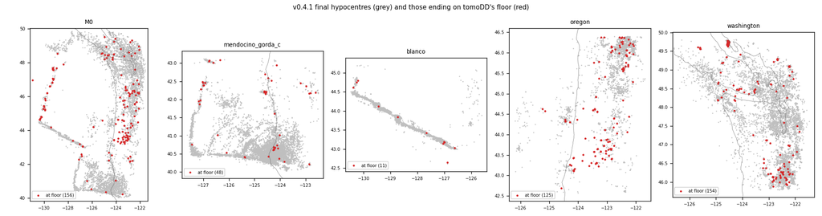

No v0.4.1 final hypocentre is above the true surface.

## 6. Model v0.4.1 - v0.4.0 on resolved nodes (inversion values, before the product rules)

Resolved = checkerboard-resolved nodes (resolution > 0, D-B049 masks); tile-covered = nodes inside a merged tile's box (tile_weight > 0). Resolution masks identical: True. Noise floors: the v0.4.1 chain and the v0.4.0 chain rerun with N(0, 1e-6 s) on every observed time, merged with the same rules. above_noise = |difference| > 2 x the largest |noise difference| (either chain) at the node and its 26 neighbours.

| quantity | nodes | depth_km | n_nodes | rms_pct | max_abs_pct | gt1_pct | noise_v041_rms_pct | noise_v040_rms_pct | noise_max_abs_pct | above_noise_pct |
| --- | --- | --- | --- | --- | --- | --- | --- | --- | --- | --- |
| Vp | resolved | all | 888 | 0.7905 | 8.19 | 12.05 | 0.8394 | 0.7384 | 9.103 | 1.58 |
| Vs | resolved | all | 320 | 0.6954 | 8.898 | 4.38 | 0.8692 | 0.8154 | 8.876 | 0 |
| Vp | tile-covered | all | 94656 | 0.1443 | 11.37 | 0.26 | 0.1395 | 0.1022 | 10.28 | 6.04 |
| Vs | tile-covered | all | 94626 | 0.0611 | 8.898 | 0.03 | 0.0651 | 0.0578 | 8.876 | 13.45 |

| quantity | nodes | depth_km | n_nodes | rms_pct | max_abs_pct | gt1_pct | noise_v041_rms_pct | noise_v040_rms_pct | noise_max_abs_pct | above_noise_pct |
| --- | --- | --- | --- | --- | --- | --- | --- | --- | --- | --- |
| Vp | resolved | 1 | 20 | 0.0866 | 0.161 | 0 | 0.0191 | 0.0123 | 0.034 | 55 |
| Vp | resolved | 3 | 38 | 0.0324 | 0.078 | 0 | 0.0124 | 0.0141 | 0.052 | 0 |
| Vp | resolved | 5 | 51 | 0.0211 | 0.049 | 0 | 0.0145 | 0.0118 | 0.035 | 0 |
| Vp | resolved | 7 | 52 | 0.0328 | 0.101 | 0 | 0.0331 | 0.0097 | 0.137 | 3.85 |
| Vp | resolved | 9 | 21 | 0.0282 | 0.047 | 0 | 0.0148 | 0.0103 | 0.03 | 0 |
| Vp | resolved | 12 | 4 | 0.0199 | 0.035 | 0 | 0.0167 | 0.0206 | 0.031 | 0 |
| Vp | resolved | 15 | 256 | 0.7607 | 3.998 | 12.5 | 0.7294 | 0.7783 | 5.262 | 0 |
| Vp | resolved | 18 | 313 | 0.827 | 4.159 | 15.97 | 0.7912 | 0.7598 | 4.853 | 0 |
| Vp | resolved | 29 | 133 | 1.203 | 8.19 | 18.8 | 1.486 | 1.056 | 9.103 | 0.75 |
| Vs | resolved | 7 | 1 | 0.0642 | 0.064 | 0 | 0.0214 | 0.1176 | 0.118 | 0 |
| Vs | resolved | 12 | 1 | 0.0869 | 0.087 | 0 | 0.1074 | 0.1073 | 0.107 | 0 |
| Vs | resolved | 15 | 188 | 0.7937 | 8.898 | 3.19 | 0.6059 | 0.7814 | 8.876 | 0 |
| Vs | resolved | 18 | 110 | 0.5382 | 2.388 | 5.45 | 1.108 | 0.8608 | 7.676 | 0 |
| Vs | resolved | 29 | 20 | 0.4695 | 1.237 | 10 | 1.374 | 0.9072 | 4.945 | 0 |
| Vp | tile-covered | -3 | 4484 | 0.1651 | 4.665 | 0.27 | 0.0092 | 0.0098 | 0.561 | 17.02 |
| Vp | tile-covered | -1 | 4484 | 0.1045 | 2.941 | 0.07 | 0.014 | 0.019 | 0.716 | 17.31 |
| Vp | tile-covered | 1 | 4484 | 0.1447 | 7.123 | 0.11 | 0.0191 | 0.0121 | 0.63 | 18.58 |
| Vp | tile-covered | 3 | 4484 | 0.1819 | 8.792 | 0.07 | 0.2875 | 0.0605 | 7.503 | 15.05 |
| Vp | tile-covered | 5 | 4484 | 0.0838 | 1.525 | 0.11 | 0.0596 | 0.0622 | 2.093 | 8.7 |
| Vp | tile-covered | 7 | 4484 | 0.0896 | 0.948 | 0 | 0.0786 | 0.0436 | 2.563 | 11.89 |
| Vp | tile-covered | 9 | 4484 | 0.0995 | 2.876 | 0.11 | 0.1009 | 0.0581 | 3.636 | 12.36 |
| Vp | tile-covered | 12 | 4484 | 0.1072 | 2.714 | 0.25 | 0.1027 | 0.1061 | 4.271 | 7.69 |
| Vp | tile-covered | 15 | 4705 | 0.2011 | 3.998 | 0.81 | 0.1832 | 0.1898 | 5.262 | 4 |
| Vp | tile-covered | 18 | 4677 | 0.2437 | 4.159 | 1.28 | 0.2284 | 0.2198 | 4.853 | 4.47 |
| Vp | tile-covered | 21 | 4484 | 0.1145 | 2.069 | 0.27 | 0.1542 | 0.1118 | 6.262 | 3.32 |
| Vp | tile-covered | 25 | 4484 | 0.1484 | 4.685 | 0.33 | 0.1628 | 0.114 | 6.136 | 0.87 |
| Vp | tile-covered | 29 | 4562 | 0.316 | 11.37 | 0.85 | 0.3329 | 0.2132 | 10.28 | 2.04 |
| Vp | tile-covered | 34 | 4484 | 0.2061 | 7.068 | 0.47 | 0.1758 | 0.1689 | 6.664 | 1.23 |
| Vp | tile-covered | 40 | 4484 | 0.1017 | 1.512 | 0.31 | 0.0916 | 0.0398 | 1.53 | 1.16 |
| Vp | tile-covered | 47 | 4484 | 0.0976 | 5.774 | 0.04 | 0.0669 | 0.0731 | 4.269 | 1.05 |
| Vp | tile-covered | 55 | 4484 | 0.0852 | 5.619 | 0.02 | 0.0225 | 0.0103 | 0.24 | 0.18 |
| Vp | tile-covered | 65 | 4484 | 0.0056 | 0.162 | 0 | 0.0122 | 0.01 | 0.602 | 0.13 |
| Vp | tile-covered | 80 | 4484 | 0.001 | 0.013 | 0 | 0.0009 | 0.001 | 0.013 | 0 |
| Vp | tile-covered | 100 | 4484 | 0 | 0 | 0 | 0 | 0 | 0 | 0 |
| Vp | tile-covered | 125 | 4484 | 0 | 0 | 0 | 0 | 0 | 0 | 0 |
| Vs | tile-covered | -3 | 4484 | 0.0999 | 4.665 | 0.09 | 0.0005 | 0.0021 | 0.096 | 14.5 |
| Vs | tile-covered | -1 | 4484 | 0.0271 | 0.7 | 0 | 0.0006 | 0.0037 | 0.161 | 27.19 |
| Vs | tile-covered | 1 | 4484 | 0.0378 | 0.677 | 0 | 0.0034 | 0.0076 | 0.375 | 36.35 |
| Vs | tile-covered | 3 | 4484 | 0.0331 | 0.778 | 0 | 0.0498 | 0.0157 | 2.515 | 34.72 |
| Vs | tile-covered | 5 | 4484 | 0.0315 | 0.669 | 0 | 0.0176 | 0.0093 | 0.556 | 31.16 |
| Vs | tile-covered | 7 | 4491 | 0.0313 | 1.312 | 0.02 | 0.0242 | 0.0261 | 1.335 | 20.08 |
| Vs | tile-covered | 9 | 4484 | 0.039 | 1.195 | 0.02 | 0.023 | 0.0259 | 1.109 | 22.12 |
| Vs | tile-covered | 12 | 4491 | 0.0973 | 6.35 | 0.02 | 0.0204 | 0.0223 | 1.054 | 17.57 |
| Vs | tile-covered | 15 | 4726 | 0.1609 | 8.898 | 0.15 | 0.1247 | 0.157 | 8.876 | 8.87 |
| Vs | tile-covered | 18 | 4645 | 0.0971 | 2.388 | 0.17 | 0.1903 | 0.1436 | 7.676 | 9.58 |
| Vs | tile-covered | 21 | 4484 | 0.0502 | 1.92 | 0.07 | 0.0508 | 0.0728 | 3.84 | 8.65 |
| Vs | tile-covered | 25 | 4484 | 0.105 | 4.816 | 0.09 | 0.1383 | 0.1034 | 6.136 | 7.58 |
| Vs | tile-covered | 29 | 4529 | 0.0393 | 1.252 | 0.07 | 0.0958 | 0.0673 | 4.945 | 4.66 |
| Vs | tile-covered | 34 | 4484 | 0.018 | 1.06 | 0.02 | 0.0076 | 0.0165 | 1.06 | 7.83 |
| Vs | tile-covered | 40 | 4484 | 0.0073 | 0.27 | 0 | 0.0052 | 0.0043 | 0.294 | 10.48 |
| Vs | tile-covered | 47 | 4484 | 0.0076 | 0.163 | 0 | 0.0019 | 0.0021 | 0.024 | 11.82 |
| Vs | tile-covered | 55 | 4484 | 0.0044 | 0.115 | 0 | 0.001 | 0.0018 | 0.023 | 4.48 |
| Vs | tile-covered | 65 | 4484 | 0.0018 | 0.024 | 0 | 0.0008 | 0.0011 | 0.024 | 2.9 |
| Vs | tile-covered | 80 | 4484 | 0.001 | 0.023 | 0 | 0 | 0 | 0 | 0.8 |
| Vs | tile-covered | 100 | 4484 | 0.0012 | 0.023 | 0 | 0.0006 | 0.0006 | 0.013 | 0.8 |
| Vs | tile-covered | 125 | 4484 | 0.0012 | 0.023 | 0 | 0.0006 | 0.0006 | 0.013 | 0.83 |

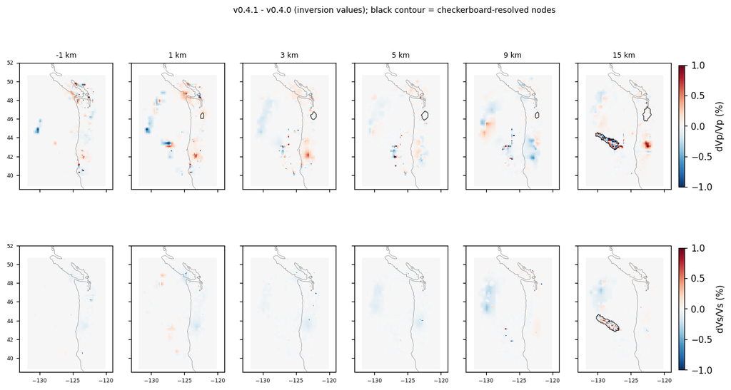

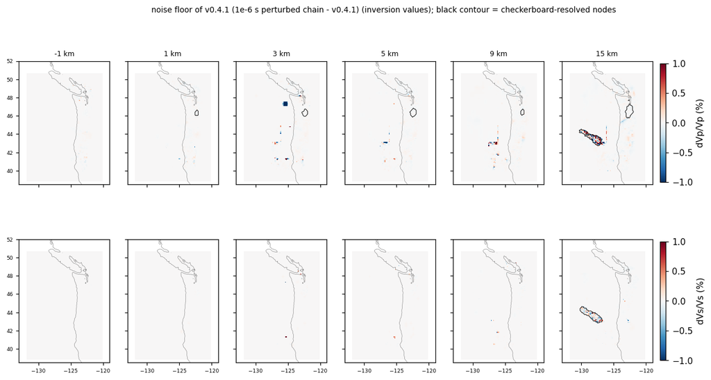

## 7. Hypocentre shifts (tomoDD final), by stage and region

| stage | comparison | region | events | dh_median_km | dh_p90_km | dz_median_km | dz_absmedian_km | dz_p90abs_km | gt1km_3d_pct |
| --- | --- | --- | --- | --- | --- | --- | --- | --- | --- |
| M0 | v0.4.1 - v0.4.0 | Axial | 22 | 0.037 | 0.194 | -0.012 | 0.021 | 0.37 | 4.5 |
| M0 | v0.4.1 - v0.4.0 | Blanco | 536 | 0.019 | 0.11 | -0.008 | 0.041 | 0.26 | 2.4 |
| M0 | v0.4.1 - v0.4.0 | Cascades | 364 | 0.008 | 0.09 | 0.001 | 0.012 | 0.186 | 3.3 |
| M0 | v0.4.1 - v0.4.0 | Explorer | 211 | 0.019 | 0.126 | -0.002 | 0.039 | 0.432 | 3.3 |
| M0 | v0.4.1 - v0.4.0 | Gorda | 827 | 0.011 | 0.061 | 0 | 0.029 | 0.27 | 2.1 |
| M0 | v0.4.1 - v0.4.0 | JdF ridge/plate | 122 | 0.083 | 0.571 | 0.047 | 0.076 | 1.897 | 19.7 |
| M0 | v0.4.1 - v0.4.0 | Mendocino | 545 | 0.006 | 0.028 | 0 | 0.008 | 0.074 | 0.7 |
| M0 | v0.4.1 - v0.4.0 | Offshore forearc | 1572 | 0.014 | 0.061 | 0.002 | 0.019 | 0.15 | 1.2 |
| M0 | v0.4.1 - v0.4.0 | Other onshore | 1403 | 0.012 | 0.084 | 0 | 0.023 | 0.273 | 3.1 |
| M0 | v0.4.1 - v0.4.0 | Puget/Georgia | 1253 | 0.012 | 0.055 | -0.001 | 0.019 | 0.128 | 1.3 |
| M0 | v0.4.1 - v0.4.0 | all | 6855 | 0.012 | 0.073 | 0 | 0.021 | 0.199 | 2.3 |
| M0 | v0.4.1 - v0.4.0 | events hit by the floor in v0.4.1 | 181 | 0.157 | 0.576 | 0.786 | 0.792 | 2.063 | 40.3 |
| M0 | v0.4.1 - v0.4.0 | events never hit | 6674 | 0.012 | 0.063 | 0 | 0.02 | 0.16 | 1.2 |
| M0 | noise floor v0.4.1 (nf - v0.4.1) | Axial | 24 | 0.001 | 0.004 | 0 | 0 | 0.007 | 0 |
| M0 | noise floor v0.4.1 (nf - v0.4.1) | Blanco | 536 | 0.008 | 0.041 | 0 | 0.016 | 0.108 | 0.7 |
| M0 | noise floor v0.4.1 (nf - v0.4.1) | Cascades | 370 | 0.004 | 0.029 | -0.001 | 0.005 | 0.07 | 0.5 |
| M0 | noise floor v0.4.1 (nf - v0.4.1) | Explorer | 211 | 0.007 | 0.092 | 0 | 0.008 | 0.165 | 2.8 |
| M0 | noise floor v0.4.1 (nf - v0.4.1) | Gorda | 828 | 0.005 | 0.031 | 0.001 | 0.012 | 0.127 | 0.8 |
| M0 | noise floor v0.4.1 (nf - v0.4.1) | JdF ridge/plate | 122 | 0.001 | 0.008 | 0 | 0 | 0.005 | 1.6 |
| M0 | noise floor v0.4.1 (nf - v0.4.1) | Mendocino | 545 | 0.003 | 0.014 | 0.001 | 0.003 | 0.036 | 0 |
| M0 | noise floor v0.4.1 (nf - v0.4.1) | Offshore forearc | 1593 | 0.003 | 0.021 | 0 | 0.003 | 0.045 | 0.2 |
| M0 | noise floor v0.4.1 (nf - v0.4.1) | Other onshore | 1454 | 0.003 | 0.017 | 0 | 0.004 | 0.048 | 0.2 |
| M0 | noise floor v0.4.1 (nf - v0.4.1) | Puget/Georgia | 1260 | 0.007 | 0.041 | 0 | 0.011 | 0.104 | 0.8 |
| M0 | noise floor v0.4.1 (nf - v0.4.1) | all | 6943 | 0.004 | 0.028 | 0 | 0.006 | 0.078 | 0.5 |
| M0 | noise floor v0.4.1 (nf - v0.4.1) | events hit by the floor in v0.4.1 | 266 | 0.002 | 0.01 | 0 | 0 | 0.006 | 0 |
| M0 | noise floor v0.4.1 (nf - v0.4.1) | events never hit | 6677 | 0.004 | 0.029 | 0 | 0.006 | 0.08 | 0.6 |
| M0 | noise floor v0.4.0 (nf - v0.4.0) | Axial | 22 | 0 | 0.002 | 0 | 0 | 0.002 | 0 |
| M0 | noise floor v0.4.0 (nf - v0.4.0) | Blanco | 536 | 0.004 | 0.036 | 0 | 0.007 | 0.084 | 0.9 |
| M0 | noise floor v0.4.0 (nf - v0.4.0) | Cascades | 364 | 0.002 | 0.013 | 0 | 0.003 | 0.042 | 1.1 |
| M0 | noise floor v0.4.0 (nf - v0.4.0) | Explorer | 211 | 0.011 | 0.068 | 0.001 | 0.012 | 0.168 | 1.9 |

[output cut: 93 more lines]

## 8. Residual rms by phase and station class

Absolute residuals of the final iteration (tomoDD.res; 'start' = v0.4.1's first iteration, same data and start as v0.4.0's); catalog dt residuals in the last row of each stage. All events of each run (v0.4.1 keeps the events v0.4.0 dropped as air quakes):

| version | stage | phase | cls | start | v0.4.0 | v0.4.1 | n_v0.4.1 | change_pct |
| --- | --- | --- | --- | --- | --- | --- | --- | --- |
|  | M0 | P | OBS | 0.4107 | 0.2396 | 0.2396 | 20103 | 0 |
|  | M0 | P | all | 0.3927 | 0.2105 | 0.2107 | 118273 | 0.1 |
|  | M0 | P | land | 0.3889 | 0.204 | 0.2042 | 98170 | 0.1 |
|  | M0 | S | OBS | 0.5216 | 0.4645 | 0.4654 | 26113 | 0.19 |
|  | M0 | S | all | 0.5772 | 0.4523 | 0.4534 | 108841 | 0.24 |
|  | M0 | S | land | 0.5936 | 0.4484 | 0.4495 | 82728 | 0.25 |
|  | M0 | dt (catalog) | all | 0.2514 | 0.2107 | 0.2115 | 275169 | 0.38 |
|  | blanco | P | OBS | 0.2764 | 0.1522 | 0.1518 | 41858 | -0.26 |
|  | blanco | P | all | 0.2764 | 0.1522 | 0.1518 | 41858 | -0.26 |
|  | blanco | S | OBS | 0.4494 | 0.2794 | 0.2788 | 42431 | -0.21 |
|  | blanco | S | all | 0.4494 | 0.2794 | 0.2788 | 42431 | -0.21 |
|  | blanco | dt (catalog) | all | 0.2442 | 0.2449 | 0.245 | 281080 | 0.04 |
|  | mendocino_gorda_c | P | OBS | 0.36 | 0.2101 | 0.21 | 37710 | -0.05 |
|  | mendocino_gorda_c | P | all | 0.3432 | 0.1924 | 0.1923 | 128910 | -0.05 |
|  | mendocino_gorda_c | P | land | 0.336 | 0.1846 | 0.1846 | 91200 | 0 |
|  | mendocino_gorda_c | S | OBS | 0.4518 | 0.399 | 0.3989 | 64093 | -0.03 |
|  | mendocino_gorda_c | S | all | 0.5168 | 0.3975 | 0.3975 | 136118 | 0 |
|  | mendocino_gorda_c | S | land | 0.5681 | 0.3963 | 0.3963 | 72025 | 0 |
|  | mendocino_gorda_c | dt (catalog) | all | 0.2464 | 0.1988 | 0.1988 | 578675 | 0 |
|  | oregon | P | OBS | 0.3122 | 0.1908 | 0.1962 | 827 | 2.83 |
|  | oregon | P | all | 0.2928 | 0.1579 | 0.1588 | 62977 | 0.57 |
|  | oregon | P | land | 0.2926 | 0.1574 | 0.1583 | 62150 | 0.57 |
|  | oregon | S | OBS | 0.4923 | 0.3297 | 0.3304 | 1041 | 0.21 |
|  | oregon | S | all | 0.4651 | 0.3139 | 0.3158 | 57422 | 0.61 |
|  | oregon | S | land | 0.4645 | 0.3136 | 0.3155 | 56381 | 0.61 |
|  | oregon | dt (catalog) | all | 0.2054 | 0.1624 | 0.1634 | 281666 | 0.62 |
|  | washington | P | OBS | 0.2794 | 0.3185 | 0.3175 | 97 | -0.31 |
|  | washington | P | all | 0.319 | 0.1815 | 0.1822 | 169980 | 0.39 |
|  | washington | P | land | 0.319 | 0.1814 | 0.1821 | 169883 | 0.39 |
|  | washington | S | OBS | 0.8256 | 0.6169 | 0.624 | 121 | 1.15 |
|  | washington | S | all | 0.5807 | 0.3681 | 0.3693 | 158131 | 0.33 |
|  | washington | S | land | 0.5804 | 0.3679 | 0.369 | 158010 | 0.3 |
|  | washington | dt (catalog) | all | 0.2136 | 0.173 | 0.1739 | 738267 | 0.52 |

Only the events kept by both v0.4.0 and v0.4.1 (same event set):

| version | stage | phase | cls | start | v0.4.0 | v0.4.1 | n_v0.4.1 | change_pct |
| --- | --- | --- | --- | --- | --- | --- | --- | --- |
|  | M0 | P | OBS | 0.4103 | 0.2396 | 0.2396 | 20085 | 0 |
|  | M0 | P | all | 0.39 | 0.2105 | 0.2105 | 117491 | 0 |
|  | M0 | P | land | 0.3857 | 0.204 | 0.204 | 97406 | 0 |
|  | M0 | S | OBS | 0.5217 | 0.4645 | 0.4652 | 26103 | 0.15 |
|  | M0 | S | all | 0.5751 | 0.4523 | 0.4529 | 108312 | 0.13 |
|  | M0 | S | land | 0.591 | 0.4484 | 0.449 | 82209 | 0.13 |
|  | M0 | dt (catalog) | all | 0.2487 | 0.2107 | 0.2113 | 273688 | 0.28 |
|  | blanco | P | OBS | 0.2761 | 0.1522 | 0.1518 | 41825 | -0.26 |
|  | blanco | P | all | 0.2761 | 0.1522 | 0.1518 | 41825 | -0.26 |
|  | blanco | S | OBS | 0.4494 | 0.2794 | 0.2787 | 42406 | -0.25 |
|  | blanco | S | all | 0.4494 | 0.2794 | 0.2787 | 42406 | -0.25 |
|  | blanco | dt (catalog) | all | 0.2441 | 0.2449 | 0.245 | 280935 | 0.04 |
|  | mendocino_gorda_c | P | OBS | 0.3533 | 0.2101 | 0.21 | 37695 | -0.05 |
|  | mendocino_gorda_c | P | all | 0.3381 | 0.1924 | 0.1922 | 128791 | -0.1 |
|  | mendocino_gorda_c | P | land | 0.3316 | 0.1846 | 0.1844 | 91096 | -0.11 |
|  | mendocino_gorda_c | S | OBS | 0.4518 | 0.399 | 0.3989 | 64079 | -0.03 |
|  | mendocino_gorda_c | S | all | 0.5166 | 0.3975 | 0.3975 | 136052 | 0 |
|  | mendocino_gorda_c | S | land | 0.5677 | 0.3963 | 0.3963 | 71973 | 0 |
|  | mendocino_gorda_c | dt (catalog) | all | 0.2463 | 0.1988 | 0.1988 | 578439 | 0 |
|  | oregon | P | OBS | 0.3077 | 0.1908 | 0.1937 | 819 | 1.52 |
|  | oregon | P | all | 0.2875 | 0.1579 | 0.1581 | 62353 | 0.13 |
|  | oregon | P | land | 0.2872 | 0.1574 | 0.1576 | 61534 | 0.13 |
|  | oregon | S | OBS | 0.4914 | 0.3297 | 0.331 | 1036 | 0.39 |
|  | oregon | S | all | 0.4613 | 0.3139 | 0.3146 | 57055 | 0.22 |
|  | oregon | S | land | 0.4607 | 0.3136 | 0.3143 | 56019 | 0.22 |
|  | oregon | dt (catalog) | all | 0.2007 | 0.1624 | 0.1629 | 279198 | 0.31 |
|  | washington | P | OBS | 0.2794 | 0.3185 | 0.3175 | 97 | -0.31 |
|  | washington | P | all | 0.3158 | 0.1815 | 0.1815 | 168658 | 0 |
|  | washington | P | land | 0.3158 | 0.1814 | 0.1814 | 168561 | 0 |
|  | washington | S | OBS | 0.8256 | 0.6169 | 0.624 | 121 | 1.15 |
|  | washington | S | all | 0.5798 | 0.3681 | 0.369 | 157283 | 0.24 |
|  | washington | S | land | 0.5794 | 0.3679 | 0.3688 | 157162 | 0.24 |
|  | washington | dt (catalog) | all | 0.2121 | 0.173 | 0.1734 | 732652 | 0.23 |

## 9. Run times

| stage | version | run | wall_min | user_min | maxrss_gb |
| --- | --- | --- | --- | --- | --- |
| M0 | v0.4.0 | margin_m0_v3/d200_s480 | 18.1 | 18.1 | 1.79 |
| M0 | v0.4.1 | margin_m0_v4/d200_s480 | 21.2 | 20.7 | 1.65 |
| M0 | v0.4.1 noise floor | margin_m0_v4nf/d200_s480 | 22 | 21.4 | 1.52 |
| mendocino_gorda_c | v0.4.0 | mendocino_gorda_c_m0t/d200_s480 | 38.1 | 38 | 2.85 |
| mendocino_gorda_c | v0.4.1 | mendocino_gorda_c_m0f/d200_s480 | 35.7 | 34.7 | 2.71 |
| mendocino_gorda_c | v0.4.1 noise floor | mendocino_gorda_c_m0fnf/d200_s480 | 36.4 | 35.4 | 2.71 |
| blanco | v0.4.0 | blanco_m0t/d200_s20 | 12.5 | 12.5 | 1.43 |
| blanco | v0.4.1 | blanco_m0f/d200_s20 | 14.7 | 14.6 | 1.27 |
| blanco | v0.4.1 noise floor | blanco_m0fnf/d200_s20 | 14.2 | 14.1 | 1.78 |
| oregon | v0.4.0 | oregon_m0t/d200_s480 | 17.8 | 17.7 | 1.15 |
| oregon | v0.4.1 | oregon_m0f/d200_s480 | 14.6 | 14.5 | 1.3 |
| oregon | v0.4.1 noise floor | oregon_m0fnf/d200_s480 | 14 | 13.9 | 0.98 |
| washington | v0.4.0 | washington_m0t/d200_s480 | 47 | 46.9 | 3.22 |
| washington | v0.4.1 | washington_m0f/d200_s480 | 46.3 | 45 | 3.07 |
| washington | v0.4.1 noise floor | washington_m0fnf/d200_s480 | 45.9 | 44.8 | 3.07 |

| job | start | end | seconds |
| --- | --- | --- | --- |
| ident_e10k | 2026-11-25T08:15:08 | 2026-11-25T08:30:13 | 905 |
| test_floor | 2026-11-25T08:15:08 | 2026-11-25T08:32:13 | 1025 |
| ident_m | 2026-11-25T08:15:08 | 2026-11-25T08:39:15 | 1447 |
| inp_m0 | 2026-11-25T08:39:15 | 2026-11-25T08:41:56 | 161 |
| inp_m0nf | 2026-11-25T08:39:15 | 2026-11-25T08:41:56 | 161 |
| ver_m0 | 2026-11-25T08:41:56 | 2026-11-25T08:42:16 | 20 |
| flr_m0 | 2026-11-25T08:42:16 | 2026-11-25T08:42:36 | 20 |
| ver_m0nf | 2026-11-25T08:42:36 | 2026-11-25T08:42:56 | 20 |
| flr_m0nf | 2026-11-25T08:42:56 | 2026-11-25T08:43:17 | 20 |
| chk_m0 | 2026-11-25T08:42:36 | 2026-11-25T08:45:17 | 161 |
| ident_e13k | 2026-11-25T08:15:08 | 2026-11-25T09:01:22 | 2774 |
| m0 | 2026-11-25T08:45:17 | 2026-11-25T09:06:43 | 1286 |
| m0nf | 2026-11-25T08:45:17 | 2026-11-25T09:07:24 | 1326 |
| inp_washington | 2026-11-25T09:06:43 | 2026-11-25T09:07:24 | 40 |
| inp_mendocino_gorda_c | 2026-11-25T09:06:43 | 2026-11-25T09:07:44 | 60 |
| ver_washington | 2026-11-25T09:07:24 | 2026-11-25T09:07:44 | 20 |
| flr_washington | 2026-11-25T09:07:44 | 2026-11-25T09:08:04 | 20 |
| ver_mendocino_gorda_c | 2026-11-25T09:08:04 | 2026-11-25T09:08:24 | 20 |
| inp_washingtonnf | 2026-11-25T09:07:44 | 2026-11-25T09:08:44 | 61 |
| flr_mendocino_gorda_c | 2026-11-25T09:08:24 | 2026-11-25T09:08:44 | 20 |
| ver_washingtonnf | 2026-11-25T09:08:44 | 2026-11-25T09:09:05 | 20 |
| flr_washingtonnf | 2026-11-25T09:08:44 | 2026-11-25T09:09:05 | 20 |
| inp_oregon | 2026-11-25T09:09:05 | 2026-11-25T09:09:25 | 20 |
| inp_mendocino_gorda_cnf | 2026-11-25T09:09:05 | 2026-11-25T09:09:45 | 40 |
| ver_oregon | 2026-11-25T09:09:25 | 2026-11-25T09:09:45 | 20 |
| ver_mendocino_gorda_cnf | 2026-11-25T09:09:45 | 2026-11-25T09:10:05 | 20 |
| flr_mendocino_gorda_cnf | 2026-11-25T09:09:45 | 2026-11-25T09:10:05 | 20 |
| flr_oregon | 2026-11-25T09:10:05 | 2026-11-25T09:10:26 | 20 |
| inp_oregonnf | 2026-11-25T09:10:05 | 2026-11-25T09:10:26 | 20 |
| ver_oregonnf | 2026-11-25T09:10:26 | 2026-11-25T09:10:46 | 20 |
| flr_oregonnf | 2026-11-25T09:10:26 | 2026-11-25T09:10:46 | 20 |
| inp_blanco | 2026-11-25T09:10:46 | 2026-11-25T09:11:06 | 20 |
| inp_blanconf | 2026-11-25T09:10:46 | 2026-11-25T09:11:26 | 40 |
| ver_blanco | 2026-11-25T09:11:06 | 2026-11-25T09:11:26 | 20 |
| flr_blanco | 2026-11-25T09:11:26 | 2026-11-25T09:11:47 | 20 |
| ver_blanconf | 2026-11-25T09:11:26 | 2026-11-25T09:11:47 | 20 |
| flr_blanconf | 2026-11-25T09:11:47 | 2026-11-25T09:12:07 | 20 |
| chk_oregon | 2026-11-25T09:10:26 | 2026-11-25T09:12:47 | 141 |
| chk_blanco | 2026-11-25T09:11:47 | 2026-11-25T09:13:47 | 121 |
| chk_mendocino_gorda_c | 2026-11-25T09:08:45 | 2026-11-25T09:14:28 | 343 |
| ident_w | 2026-11-25T08:15:08 | 2026-11-25T09:22:30 | 4042 |
| run_oregonnf | 2026-11-25T09:12:47 | 2026-11-25T09:26:51 | 844 |
| run_oregon | 2026-11-25T09:12:47 | 2026-11-25T09:27:31 | 884 |
| run_blanconf | 2026-11-25T09:13:48 | 2026-11-25T09:28:12 | 864 |
| run_blanco | 2026-11-25T09:13:48 | 2026-11-25T09:28:32 | 884 |
| chk_washington | 2026-11-25T09:22:30 | 2026-11-25T09:29:32 | 422 |
| run_mendocino_gorda_c | 2026-11-25T09:14:28 | 2026-11-25T09:50:18 | 2150 |
| run_mendocino_gorda_cnf | 2026-11-25T09:14:28 | 2026-11-25T09:50:58 | 2190 |
| run_washingtonnf | 2026-11-25T09:29:32 | 2026-11-25T10:15:45 | 2772 |
| run_washington | 2026-11-25T09:29:32 | 2026-11-25T10:16:05 | 2793 |
| merge_nf | 2026-11-25T10:15:45 | 2026-11-25T10:16:05 | 20 |
| merge | 2026-11-25T10:16:05 | 2026-11-25T10:16:25 | 20 |
| summaries | 2026-11-25T10:16:05 | 2026-11-25T10:16:25 | 20 |
| prod_nodes | 2026-11-25T10:16:25 | 2026-11-25T10:16:45 | 20 |
| prod_nll | 2026-11-25T10:16:45 | 2026-11-25T10:18:46 | 121 |
| prod_register | 2026-11-25T10:18:46 | 2026-11-25T10:19:06 | 20 |

## 10. Product and registration

```
{
 "registration": [
  {
   "model": "cascadia_obs_tomo",
   "version": "0.4.1",
   "status": "candidate",
   "created": "2026-11-25T18:18:46+00:00",
   "description": "v0.4.0 (v0.3.1 configuration, re-timed picks) re-inverted with tomoDD's event updates floored at the local solid surface (D-B081 floor in the inversion, D-B083); product as D-B076: medium (rock / water / air at the D-B068 merged surface), D-B073 shallow-crust node rule, Vp_tomography / Vs_tomography = the inversion values, NonLinLoc grids by the field rule",
   "run": "merge: mendocino_gorda_c_m0f/d200_s480, blanco_m0f/d200_s20, oregon_m0f/d200_s480, washington_m0f/d200_s480",
   "git_commit": "94b084dca1a3a30bfc6991572a46e1553f54891f",
   "zarr": "/wd1/mdenolle_data/tomo_v1/models/cascadia_obs_tomo/v0.4.1.zarr",
   "zarr_sha256": "6d0cb1ee550473f6d31d68cc5a7ee1698d8fc3061a35982d0f5bc3d58d25bc45",
   "netcdf": "/wd1/mdenolle_data/tomo_v1/models/cascadia_obs_tomo/v0.4.1.nc",
   "netcdf_sha256": "88370da494332869040955d167d933596dc2f775c153478d5b793e66000d2d81",
   "netcdf_git": "data/tomo_v1/models/cascadia_obs_tomo/v0.4.1.nc",
   "nll": "/wd1/mdenolle_data/tomo_v1/models/cascadia_obs_tomo/v0.4.1_nll"
  }
 ],
 "info": {
  "nodes": 232932,
  "rock": 203988,
  "water": 8538,
  "air": 20406,
  "offshore_columns": 6791,
  "columns_outside_lattice": 108,
  "outside_lattice_below_sea_level": 6,
  "rule_nodes": 9585,
  "rule_changed": 8739,
  "water_dws_p_gt0": 405,
  "air_dws_p_gt0": 1332,
  "offshore_above_surface": 22108,
  "onshore_above_surface": 6836,
  "above_surface_vp_median": 4.718863010406494,
  "above_surface_vs_median": 2.4756360054016113,
  "by_depth": {
   "-3": {
    "water": 0,
    "air": 11091,
    "rule_changed": 0
   },
   "-1": {
    "water": 0,
    "air": 9315,
    "rule_changed": 0
   },
   "1": {
    "water": 6032,
    "air": 0,
    "rule_changed": 765
   },
   "3": {
    "water": 2506,
    "air": 0,
    "rule_changed": 2878
   },
   "5": {
    "water": 0,
    "air": 0,
    "rule_changed": 4882
   },
   "7": {
    "water": 0,
    "air": 0,
    "rule_changed": 214
   },
   "9": {
    "water": 0,
    "air": 0,
    "rule_changed": 0
   }
  },
  "rule_dvs_pct_median_max": [
   14.49,
   23.81
  ]
 },
 "checks": {
  "Vp_nc_eq_zarr": true,
  "Vs_nc_eq_zarr": true,
  "VpVs_nc_eq_zarr": true,
  "medium_nc_eq_zarr": true,
  "shallow_crust_node_nc_eq_zarr": true,
  "Vp_tomography_nc_eq_zarr": true,
  "Vs_tomography_nc_eq_zarr": true,
  "vp_rock_eq_inversion": true,
  "vs_rock_unchanged_off_rule": true,
  "vp_water_1p5": true,
  "vs_nan_above": true,
  "vp_air_nan": true,
  "vpvs_min_rule_nodes": 2.0999999046325684,
  "vpvs_rock_min_max": [
   1.5999999046325684,
   2.733883857727051
  ],
  "tomography_eq_merge": true,
  "other_vars_eq_merge": {
   "Vp_start": true,
   "Vs_start": true,
   "Vp_perturbation": true,
   "Vs_perturbation": true,
   "dws_p": true,
   "dws_s": true,
   "resolution_p": true,
   "resolution_s": true,
   "n_tiles": true,
   "tile_weight_p": true,
   "tile_weight_s": true,
   "vs_reverted": true
  }
 },
 "nll": {
  "P": {
   "md5": "52fff8c47faf3c4223c80e1bb6da383d",
   "work_md5": "52fff8c47faf3c4223c80e1bb6da383d"
  },
  "S": {
   "md5": "1105aadd408cc0d53db681d83f81034c",
   "work_md5": "1105aadd408cc0d53db681d83f81034c"
  }
 }
}
```